# What are the factors of Twitch Rankings?

By: John Idiagbonya Jr

# Introduction

In this tutorial we will be using the Data Science Pipeline to analyze how differnet games preformed on Twitch and try to isolate factors that can help us predict rankings of games on Twitch. We'll talk more about WHAT we can do with this at the end but for now let's start with HOW we find this information.

```python
import pandas as pd
import numpy as np
import matplotlib.pyplot as plt
plt.rcParams["figure.figsize"]=10,10 # sets all out plots to 10in X 10in
from sklearn.linear_model import LinearRegression
import statsmodels.api as sm
import seaborn
```

## Data collection/curation + parsing (Talk about what the data is)

We first have to read the data from the csv file into a dataframe object.

```python
twitch_games = pd.read_csv('Twitch_game_data.csv')
twitch_games.head()
```

|  | Rank | Game | Month | Year | Hours_watched | Hours_Streamed | Peak_viewers | Peak_channels | Streamers | Avg_viewers | Avg_channels | Avg_viewer_ratio |
| --- | --- | --- | --- | --- | --- | --- | --- | --- | --- | --- | --- | --- |
| 0 | 1 | League of Legends | 1 | 2016 | 94377226 | 1362044 hours | 530270 | 2903 | 129172 | 127021 | 1833 | 69.29 |
| 1 | 2 | Counter-Strike: Global Offensive | 1 | 2016 | 47832863 | 830105 hours | 372654 | 2197 | 120849 | 64378 | 1117 | 57.62 |
| 2 | 3 | Dota 2 | 1 | 2016 | 45185893 | 433397 hours | 315083 | 1100 | 44074 | 60815 | 583 | 104.26 |
| 3 | 4 | Hearthstone | 1 | 2016 | 39936159 | 235903 hours | 131357 | 517 | 36170 | 53749 | 317 | 169.29 |
| 4 | 5 | Call of Duty: Black Ops III | 1 | 2016 | 16153057 | 1151578 hours | 71639 | 3620 | 214054 | 21740 | 1549 | 14.03 |

Sometimes when you pull already curated data there can be missing entries. In this case if there are we wish to remove those rows. We choose to do this instead of filling them with zeros or some other place holder data because they would still contribute to calculations containing averages of the entire dataset potentially skewing it. Another approach you could take would be to try and fill in the missing data with averages from what other silimar entries contained. We will stick to just removing these entire rows here as this has the least bias to be implemented directly by us. (Note this may still introduce a bias)

```python
twitch_games.dropna(inplace = True)
```

Next we decide whether or not some columns are necessry for our analysis. Remove of these colums can make data easier to process and analyze.

Games on Twitch can have a sudden rise given the time peirod they take place in, ie. Among Us or Fall Guys during Covid-19, without the proper context to evaluate of games in these time peirods it would not be good to consider time period a factor.

As such we chose to ignore year and month since you can't gather context from what might have happened during that specific time period that may have contributed to the game, nor can you predict that occurance again.

```python
twitch_games = twitch_games.drop(['Month', 'Year'], axis=1)
```

Lastly, before we start to actually look at the data we want to make sure columns are in their proper types. As you may have noticed the column 'Hours_Streamed' contains numbers and strings. This column's type is object instead of an int. This will make it difficult to compare this column to others. As such we have to remove the strings from each entry in the column and change the their type to an int.

```python
arr = []
for i in twitch_games['Hours_Streamed']:
 # i.replace(' hours','') removes the string hours and replaces it with an
 # empty string. We then add this corrected entry into are array
 arr.append(i.replace(' hours',''))

# We set the column 'Hours_Streamed' to be replaced by this arr with the
# corrected entries and then change their type to be an int.
twitch_games['Hours_Streamed'] = arr
twitch_games['Hours_Streamed'] = twitch_games['Hours_Streamed'].astype(int)
twitch_games['Hours_Streamed']
```

```
0        1362044
1         830105
2         433397
3         235903
4        1151578
          ...
12945      32823
12946      85645
12947      12079
12948     142933
12949      50789
Name: Hours_Streamed, Length: 12949, dtype: int64
```

You thought we wer done? NOPE one last thing before we actually look at the data this time. There is a lot of data to plot here, you may think the mroe data the better right? And in some cases yes, but for our case since we wish to limit the noise that may occur because of the amount of data and potential outliers we will be taken the average of each factor for each game. This will help reduce the noise from outliers by helping us gauge average performance. Also games that are ranked highly on average might should a noticeable trend that we can use to our advantage.

```python
# groups the table by games and take the average of all the factors per game
avg_perfromance = twitch_games.groupby('Game').mean()
# Orders the table based on rankings
avg_perfromance = avg_perfromance.sort_values(by=['Rank']).reset_index()
avg_perfromance.head()
```

|  | Game | Rank | Hours_watched | Hours_Streamed | Peak_viewers | Peak_channels | Streamers | Avg_viewers | Avg_channels | Avg_viewer_ratio |
| --- | --- | --- | --- | --- | --- | --- | --- | --- | --- | --- |
| 0 | League of Legends | 1.661538 | 1.002618e+08 | 1.991158e+06 | 578782.846154 | 4665.753846 | 167806.876923 | 137580.200000 | 2730.800000 | 55.221231 |
| 1 | Just Chatting | 3.151515 | 1.282245e+08 | 1.780357e+06 | 554115.212121 | 4615.606061 | 244489.000000 | 175892.333333 | 2441.393939 | 71.784848 |
| 2 | Fortnite | 4.297872 | 8.665750e+07 | 5.747319e+06 | 614446.574468 | 25761.510638 | 606446.851064 | 118750.127660 | 7876.808511 | 15.923404 |
| 3 | Counter-Strike: Global Offensive | 5.461538 | 4.409524e+07 | 9.034932e+05 | 440612.246154 | 2487.353846 | 122408.384615 | 60543.092308 | 1239.046154 | 50.528000 |
| 4 | Dota 2 | 5.676923 | 4.055437e+07 | 4.438242e+05 | 302869.569231 | 1173.338462 | 31880.569231 | 55611.215385 | 608.323077 | 97.407538 |

All these steps may seem tedious but it makes it so the analyzing the data is easier later and that there are no elements that would sully the data present. This is why data cleaning is a cruicial part of the Data Science Pipeline.

## Data management/representation

Now we will begin actually plot the data and trying to look for any intresting insights. This will help us form out hypotheses later on. As rank is what we want to see how the other columns influence we will place it on the y axis and the other columns on the x.

While you could go into this with an educated guess on which factor would mostly likely be coorelated with rank you must be careful. Going in looking for only that coorelation could introduce you to bias and turn away other possible coorelations. Here we simply just plot rank against all of the factors and try to see what coorelations we can spot.

(Also remember the higher ranked a game is the lower on the why axis it will be, be sure to remember this in order not to interpret the data wrong.)

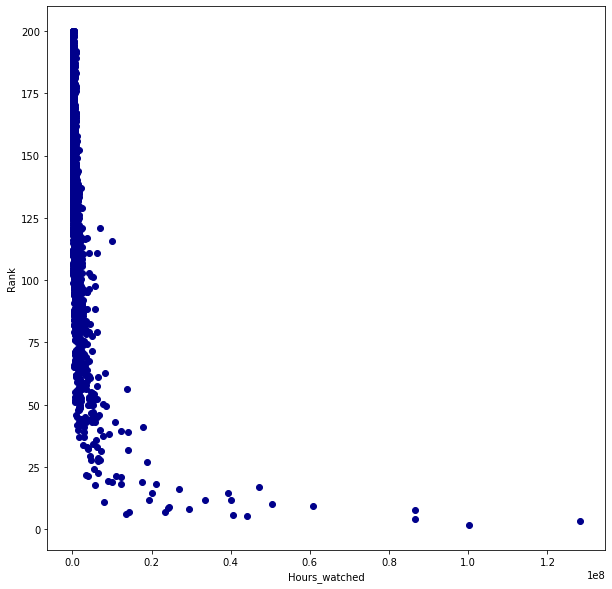

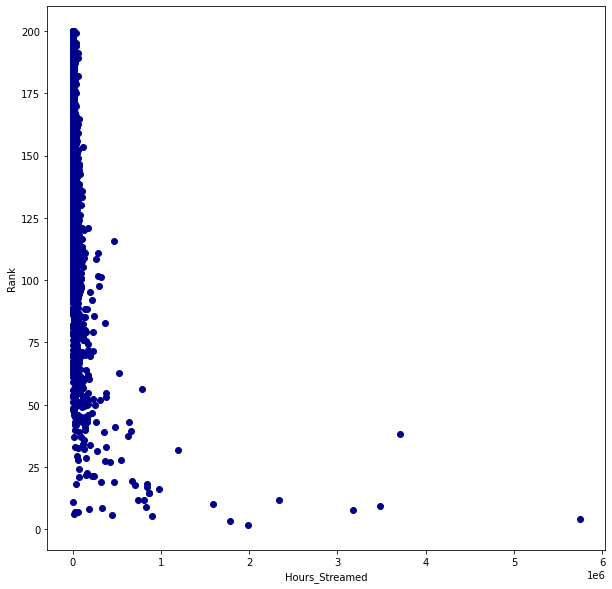

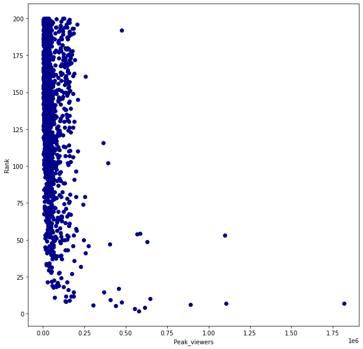

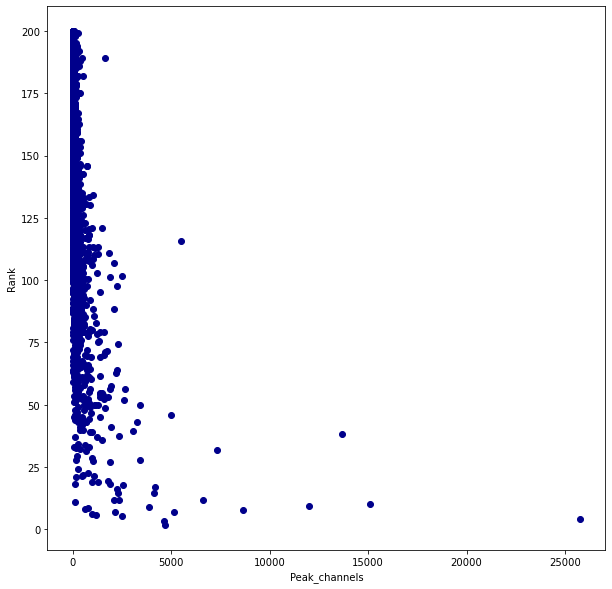

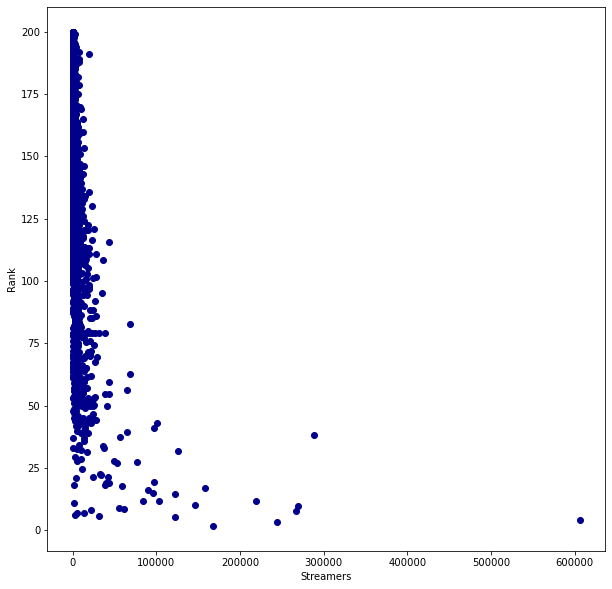

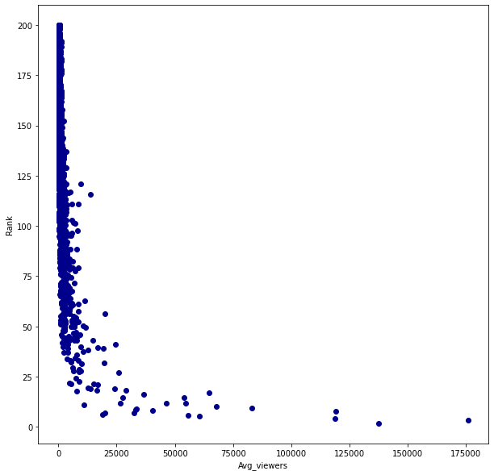

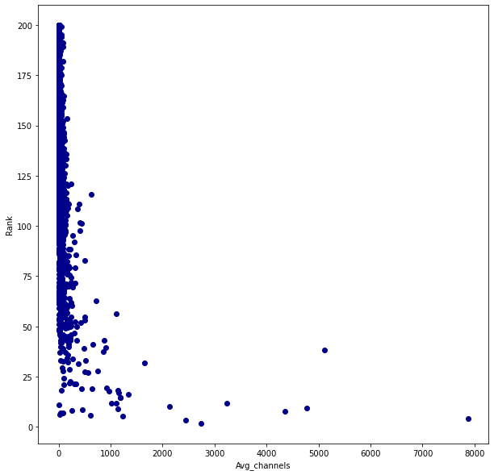

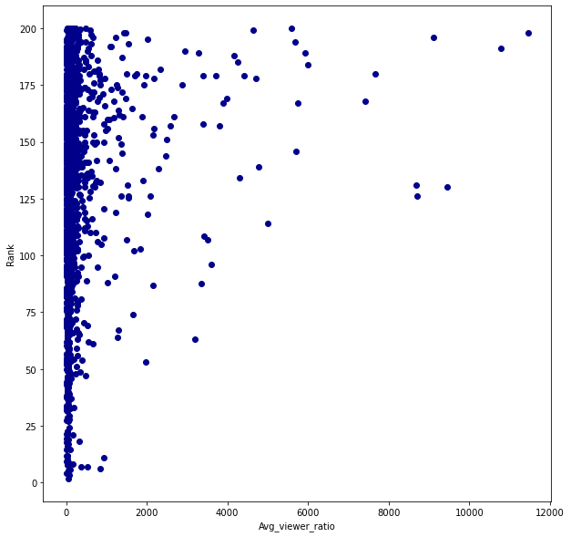

```python
for i in avg_perfromance.columns.drop(['Game', 'Rank']): #excludes the columns game and rank from out factors

  fig, ax = plt.subplots()

  #plot all of these factors against rank
  ax.scatter(x=avg_perfromance[i], y=avg_perfromance['Rank'], color='DarkBlue')
  ax.set_xlabel(i)
  ax.set_ylabel('Rank')

  plt.show()
```

Now you may be able to spot out some coorelations already but you may have also noticed that the plots where somewhat squished to the left. There might be a lot of intresting interactions there that we can't see!

Don't worry, we can get a looksie inside by using by scaling the plot by log. This won't change the data itself, it only spreads the points out so that they are easier for us to analyze with our eyes.

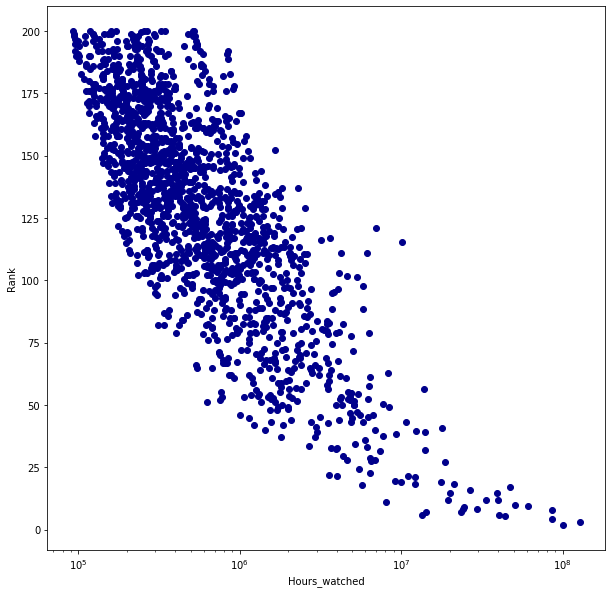

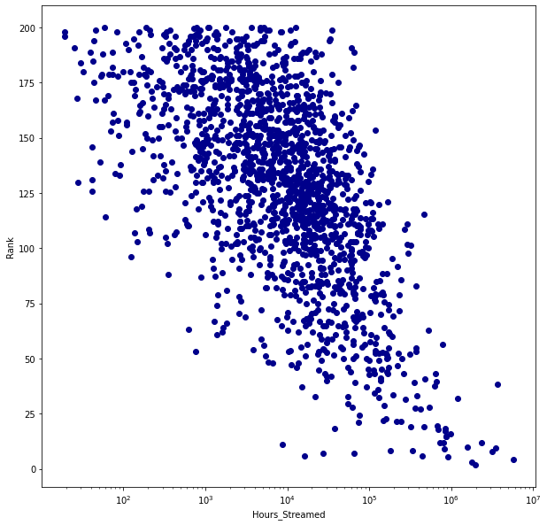

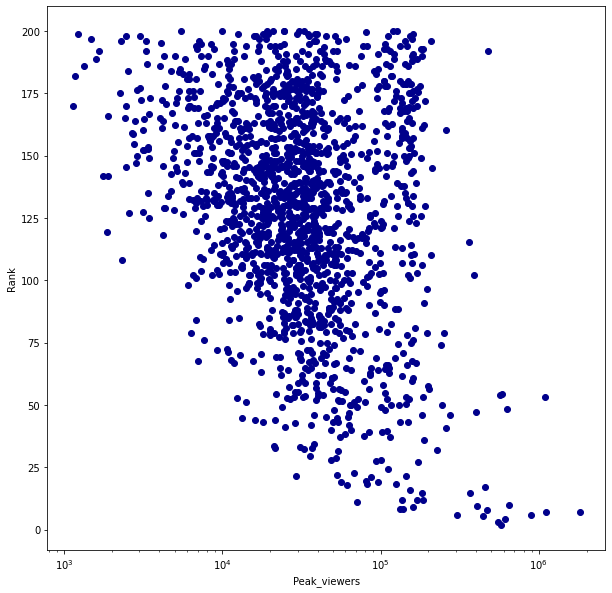

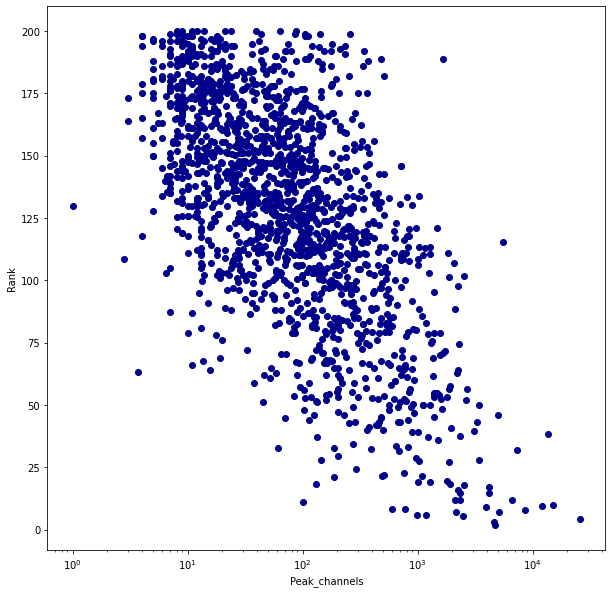

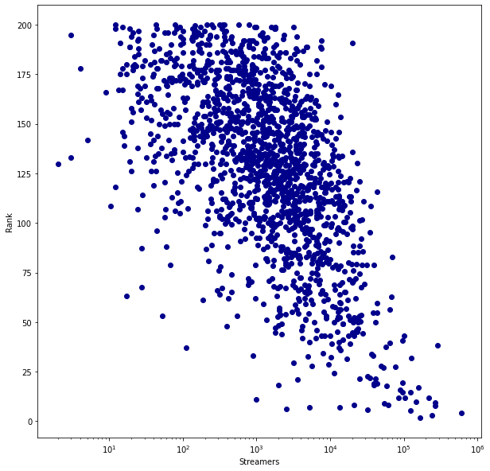

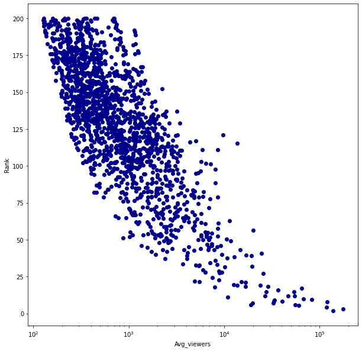

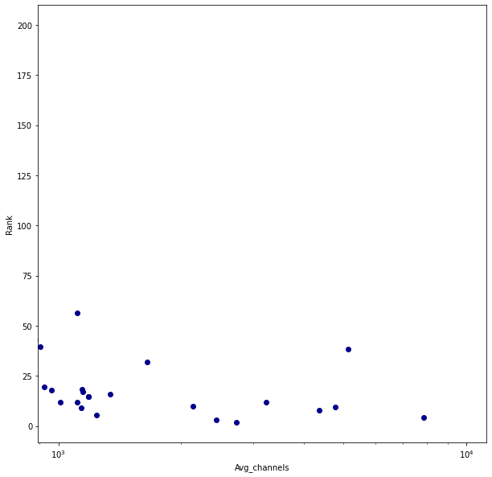

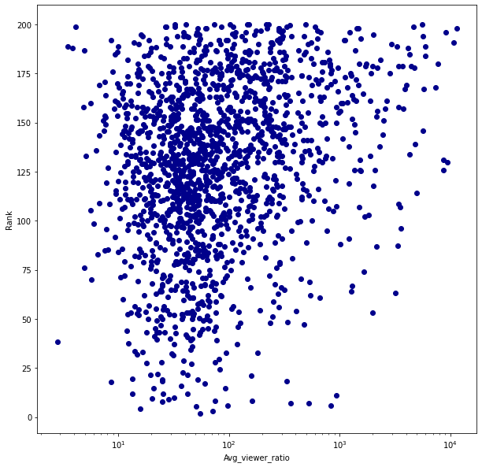

```python
for i in avg_perfromance.columns.drop(['Game', 'Rank']):

  fig, ax = plt.subplots()

  ax.scatter(x=avg_perfromance[i], y=avg_perfromance['Rank'], color='DarkBlue')
  ax.set_xlabel(i)
  ax.set_ylabel('Rank')
  plt.xscale('log') # does not change the data itself but helps spreads points out so that they are easier to analyze

  plt.show()
```

## Exploratory Data Analysis

Now we can see a lot more detail on the interactions these factors have with ranks! You may have noticed that some of the plots have a majority of the points missing. This is because of how much these points where spread out. This limits how much we can analyze them using log but it is okay we can still use what we say in the plots before transforming them with log to analzye interactions.

You may have also noticed that some graphs very clearly show some sort of relationship between ranks and factors. Let's try to pick them out and even rank which one's we think might be better.

High Signs of Coorelation: Hours_watched, Avg_viewers

These all show potential for high coorelation as their plots can clearly show a genreal trend occuring with most of the data with very few outliers.

Some Signs of Coorelation: Hours_Streamed, Peak_viewers, Peak_channels

These show a general trend for most of the data point but are not as concentrated as the previous ones. They may be good indicators but their reliability is still to be observed.

Low signs of Coorelation: Streamers, Avg_channels

Using the previous plots since on these log sclaed plot we can't draw much conclusions, it appears as if there is very little coorelation between these factors and rank but not none. While the do have higher amount of these factors associcatied with higher rankings they also have quite a few high rankings without being high in value of those factors. As such they appear to be a less reliable indicator of rank.

No Signs of Correlations: Intrestingly the average view per chanenl show that lower ranked games have the highest viewership per channel. This could suggest that in the higher ranked ones while a lot of people are stream these games most people only wacth a select few. Could this be a factor to determine which games are highly ranked?

## Hypothesis testing

Our null hypothesis has two parts:

First that there is no relation between any individual factors we have in the table and rankings for games.

And second that there is no relation between any combination of factors we have in the table and rankings for games.

Our hypothesis is that there is indeed a relationship between individual or combination of factors in the table and ranking for games and that we can use them to predict rankings.

If you remember previously, looking at the data was hard because it was so squished so we used a logarithmic transformation in order to see them better. We will do the same thing here but instead of on the scaling of the plots we will do it on the data points themselves. This still won't change data but will allow us to more accurately calculate the data by linear regressions. If you wish to learn more about logarithmic transformation visit this site: https://cdn.graphpad.com/faq/1487/file/1487logaxes.pdf

```python
# apply log(x+1) element-wise to a subset of columns
df_log = avg_perfromance.drop(['Game', 'Rank'], axis=1).applymap(lambda x: np.log(x+1))

# rename columns
df_log.columns = 'log_' + df_log.columns


df_log['Rank'] = avg_perfromance['Rank']

# shift the index
df_log.index = df_log.index + 1
df_log.head()
```

|  | log_Hours_watched | log_Hours_Streamed | log_Peak_viewers | log_Peak_channels | log_Streamers | log_Avg_viewers | log_Avg_channels | log_Avg_viewer_ratio | Rank |
| --- | --- | --- | --- | --- | --- | --- | --- | --- | --- |
| 1 | 18.423295 | 14.504227 | 13.268684 | 8.448219 | 12.030575 | 11.831970 | 7.912716 | 4.029294 | 1.661538 |
| 2 | 18.669293 | 14.392325 | 13.225130 | 8.437415 | 12.406930 | 12.077633 | 7.800734 | 4.287508 | 3.151515 |
| 3 | 18.277474 | 15.564244 | 13.328479 | 10.156676 | 13.315374 | 11.684785 | 8.971805 | 2.828698 | 4.297872 |
| 4 | 17.601862 | 13.714025 | 12.995923 | 7.819377 | 11.715126 | 11.011127 | 7.122904 | 3.942125 | 5.461538 |
| 5 | 17.518154 | 13.003186 | 12.621061 | 7.068460 | 10.369783 | 10.926158 | 6.412349 | 4.589117 | 5.676923 |

Now let's try and plot a linear regression between each of these factors and Ranks!

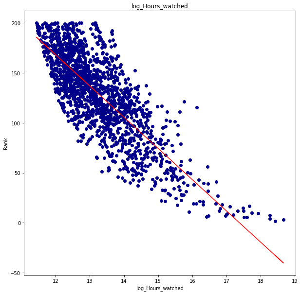

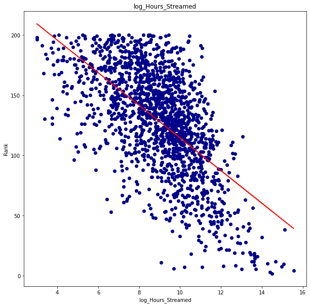

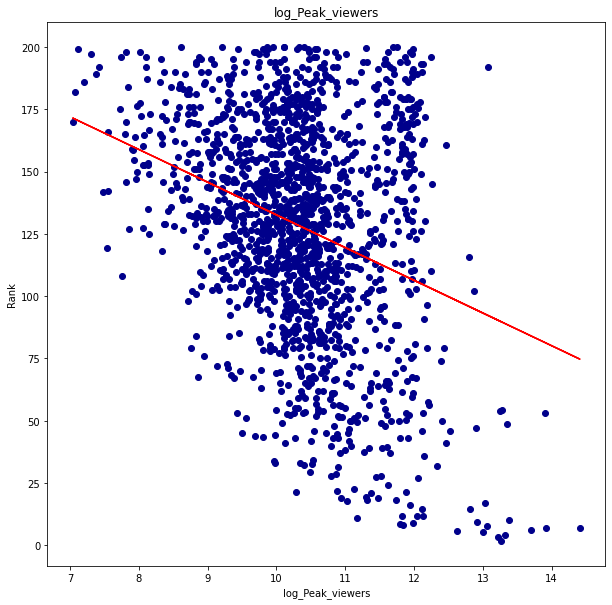

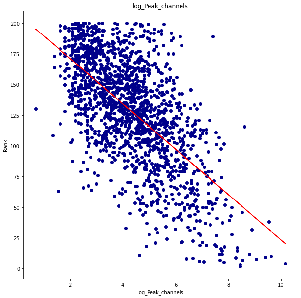

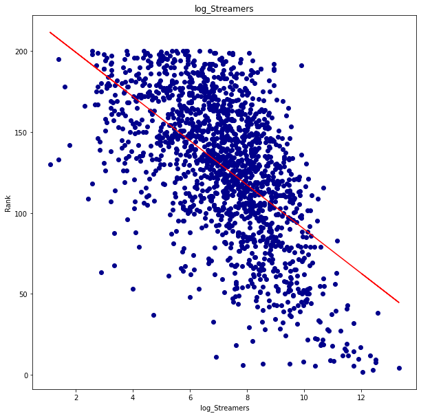

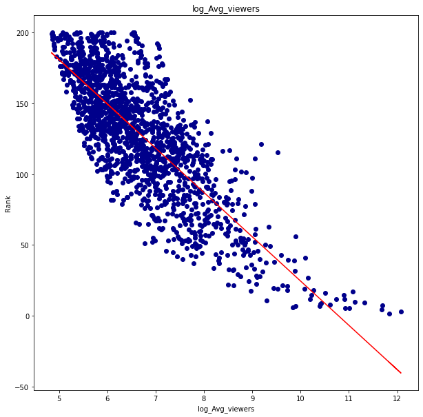

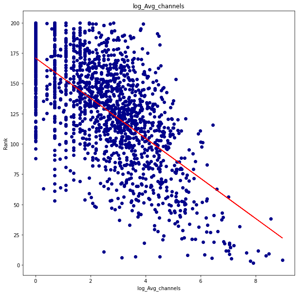

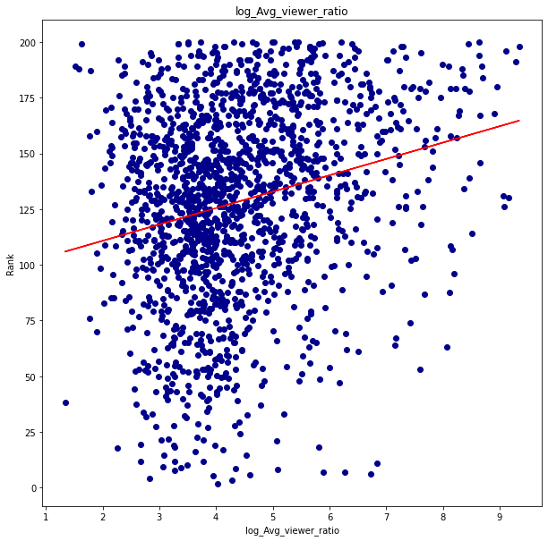

```python
for i in df_log.drop(['Rank'], axis=1):
  fig, ax3 = plt.subplots()
  X = df_log[i].values.reshape(-1, 1)
  Y = df_log.Rank.values.reshape(-1, 1)



  # This creates a linear regression and fits it to out data
  linear_regressor = LinearRegression()
  linear_regressor.fit(X, Y)
  # this the predicted Y for X ie what the line of best fit is
  Y_pred = linear_regressor.predict(X)



  ax3.scatter(x=df_log[i], y=df_log['Rank'], color='DarkBlue')
  ax3.plot(X, Y_pred, color='red')
  ax3.set_xlabel(i)
  ax3.set_ylabel('Rank')
  ax3.set_title(i)
```

It seems like the factors we identified as having possible high coorelations have really well fitted linear regressions. However, there are some such as Streamers, Avg_channels anmd especially Avg_viewer_ratio that the linear regression doesn't fit well.

There are a couple of ways we can look more closely at how these linear regression performed. One of which is a Ordinary least squares (OLS) regression. This type of regression helps identifies the relationship between independent and dependent variables. To read more about it visit: https://www.geeksforgeeks.org/ordinary-least-squares-ols-using-statsmodels/

We will take the OLs regression of each of the factors against Ranks.

```python
for i in df_log.columns.drop(['Rank']): # for all the columns except for rank
  X = df_log[i].values.reshape(-1, 1)
  Y = df_log.Rank.values.reshape(-1, 1)
  linear_regressor = LinearRegression()
  linear_regressor.fit(X, Y)
  Y_pred = linear_regressor.predict(X)

  # This time we take out X and Y and plug them into the OLS function
  results = sm.OLS(Y, X).fit()
  print(i, ': ', results.summary())
  print('\n')
```

```
log_Hours_watched :                                   OLS Regression Results
=======================================================================================
Dep. Variable:                      y   R-squared (uncentered):                   0.854
Model:                            OLS   Adj. R-squared (uncentered):              0.854
Method:                 Least Squares   F-statistic:                              9692.
Date:                Wed, 21 Jul 2021   Prob (F-statistic):                        0.00
Time:                        17:50:42   Log-Likelihood:                         -8870.4
No. Observations:                1654   AIC:                                  1.774e+04
Df Residuals:                    1653   BIC:                                  1.775e+04
Df Model:                           1
Covariance Type:            nonrobust
==============================================================================
                 coef    std err          t      P>|t|      [0.025      0.975]
------------------------------------------------------------------------------
x1             9.3863      0.095     98.446      0.000       9.199       9.573
==============================================================================
Omnibus:                      117.731   Durbin-Watson:                   0.024
Prob(Omnibus):                  0.000   Jarque-Bera (JB):              141.969
Skew:                          -0.707   Prob(JB):                     1.48e-31
Kurtosis:                       3.243   Cond. No.                         1.00
==============================================================================

Notes:
[1] R² is computed without centering (uncentered) since the model does not contain a constant.
[2] Standard Errors assume that the covariance matrix of the errors is correctly specified.


log_Hours_Streamed :                                   OLS Regression Results
=======================================================================================
Dep. Variable:                      y   R-squared (uncentered):                   0.785
Model:                            OLS   Adj. R-squared (uncentered):              0.785
Method:                 Least Squares   F-statistic:                              6027.
Date:                Wed, 21 Jul 2021   Prob (F-statistic):                        0.00
Time:                        17:50:42   Log-Likelihood:                         -9193.0
No. Observations:                1654   AIC:                                  1.839e+04
Df Residuals:                    1653   BIC:                                  1.839e+04
Df Model:                           1
Covariance Type:            nonrobust
==============================================================================
                 coef    std err          t      P>|t|      [0.025      0.975]
```

[output cut: 159 more lines]

```
Covariance Type:            nonrobust
==============================================================================
                 coef    std err          t      P>|t|      [0.025      0.975]
------------------------------------------------------------------------------
x1            27.3791      0.270    101.264      0.000      26.849      27.909
==============================================================================
Omnibus:                       33.179   Durbin-Watson:                   0.961
Prob(Omnibus):                  0.000   Jarque-Bera (JB):               34.741
Skew:                          -0.341   Prob(JB):                     2.86e-08
Kurtosis:                       3.199   Cond. No.                         1.00
==============================================================================

Notes:
[1] R² is computed without centering (uncentered) since the model does not contain a constant.
[2] Standard Errors assume that the covariance matrix of the errors is correctly specified.
```

Let's take a look at the R-squared values. R-squared is measerused from 0 to 1 and tells you how well your model fits your data. The higher typically the better. Amoung all the factors only Avg_channels has a less than 50% R-squared values. The highest is held by Peak_viewers at 87.3% suggesting it fits the data quite well. But let's conlect more evidence on how well our regressions performed. Here is more info on R-squared: https://www.investopedia.com/terms/r/r-squared.asp

Let's look at the P>|t| or p-value for all of these factors next. The p-value is the probability of obtaining results that are as extreme or more as the regression's prediction.

For this tutorial all p-values of 0.05 or less are statistically significant. It indicates strong evidence against the null hypothesis. You can read more about p-values here: https://www.investopedia.com/terms/p/p-value.asp

All of are p-values are 0 and are therefore statistically significant. That must mean we've rejected the null hypothesis right?! Not quite. Unfortuantely, even with you're naked eye you can see that while the linear regressions seem to follow the general trend for most of the plots, a lot of the actual points around the can lie very far from lines. As such we can tell there there is some discrepancies between the predicted ranks and the actual ranks. To gain more insight on this we will use residuals.

Here's more info on why we should check residuals: https://blog.minitab.com/en/adventures-in-statistics-2/regression-analysis-how-do-i-interpret-r-squared-and-assess-the-goodness-of-fit

Residuals are the difference between the actual outcome and the predicted one of the linear regression. A value of 0 would mean that the actual outcome and predict outcome where the same deviation from this in either way go to show whter the prediction was over or under the actually outcome.

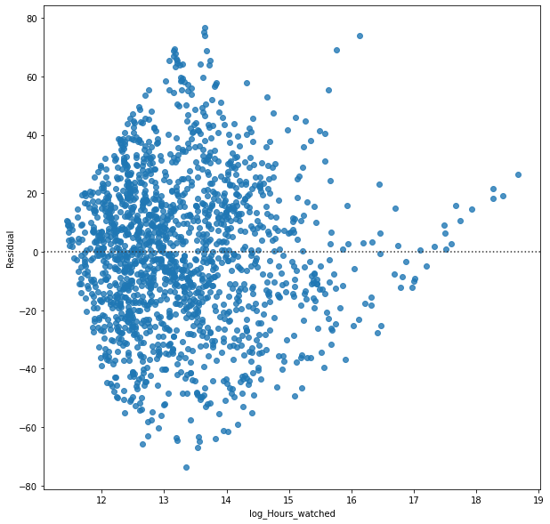

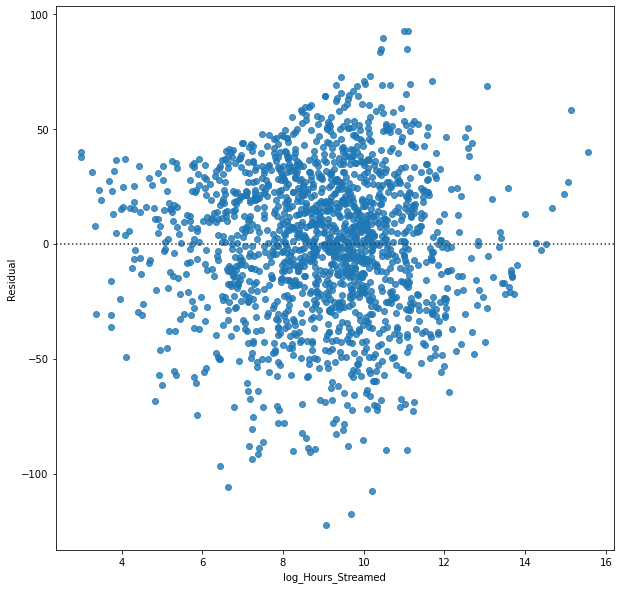

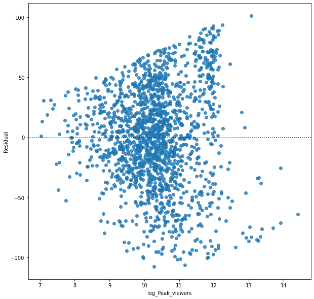

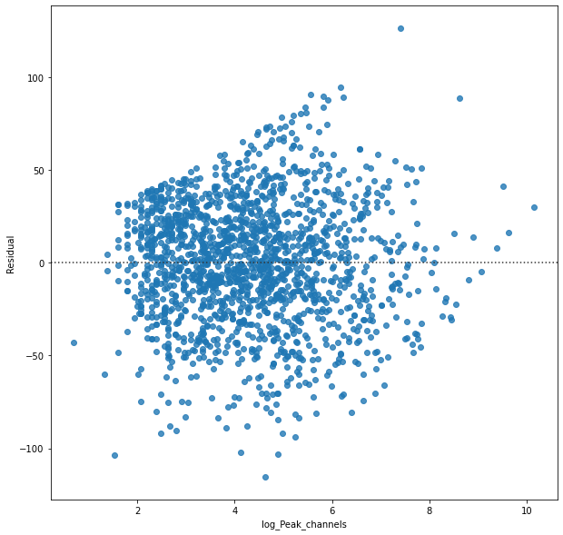

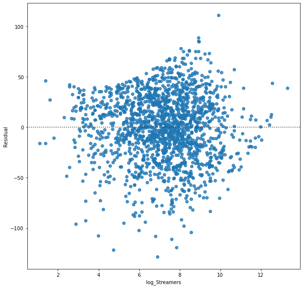

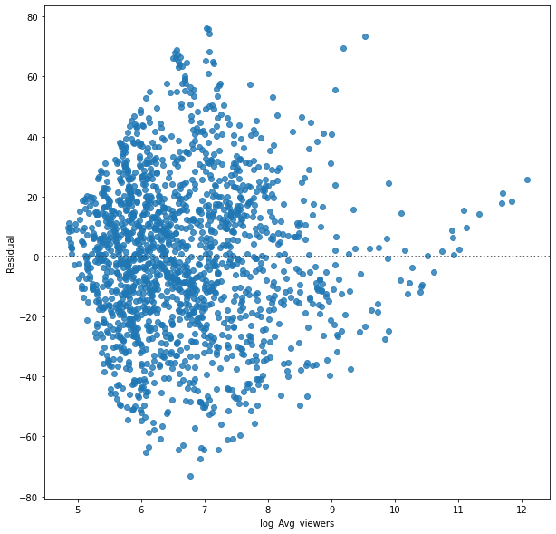

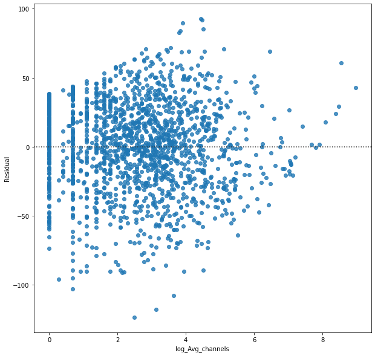

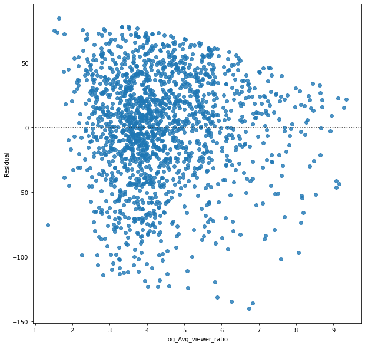

```python
for i in df_log.columns.drop(['Rank']):
  X = df_log[i].values.reshape(-1, 1)
  Y = df_log.Rank.values.reshape(-1, 1)
  linear_regressor = LinearRegression()
  linear_regressor.fit(X, Y)
  Y_pred = linear_regressor.predict(X)

  fig, ax4 = plt.subplots()
  seaborn.residplot(x=X, y=Y, order=2) # returns a plot of the residuals of linear regressions
  ax4.set_xlabel(i)
  ax4.set_ylabel('Residual')
```

As you can see the residuals show that while for some data points the linear regressions where accurate for a majority of them the were very off. Despite what the R-squared and p-values showed the linear regressions we got can not be used to make predictions on ranks. However, they do help in proving there is some relationship between these factors and ranking greatly. So while we can reject the null hypthesis that there is no relationship between any of the factors and ranks, we cannot confidently claim that there is a relationship between individual factors and ranks.

What about the other part of our null hypothesis? That there is no relationship between a combination of factors and ranks. Well I'm glad you asked!

This would make us look at the factors as no longer as simple linear regressions but multiple linear regressions whereas the coeffiecents of each contribute to the calculation of ranks. Ie., some combinations of measuring the factors will help determine what rank you will get. Read more about Simple and Multiple linear regressions here: https://towardsdatascience.com/simple-and-multiple-linear-regression-with-python-c9ab422ec29c

By the nature of multiple linear regression it becomes hard to plot the regression lines as it no longer is in 2 dimensions. As such we will just show the value of the coeffcients for the regresssion.

```python
X = df_log.drop(['Rank'], axis=1)
Y = df_log.Rank
linear_regressor = LinearRegression()
linear_regressor.fit(X, Y)
Y_pred = linear_regressor.predict(X)


for name,co in zip(X.columns, linear_regressor.coef_):
    print(name,': ', co)
```

```
log_Hours_watched :  2.765696909756878
log_Hours_Streamed :  -2.1555356348004615
log_Peak_viewers :  3.4516303447923544
log_Peak_channels :  -2.366662307731875
log_Streamers :  -2.1111572109303007
log_Avg_viewers :  -35.01634601023774
log_Avg_channels :  6.042438425879341
log_Avg_viewer_ratio :  -0.8370849332389725
```

Lets call OLS on this again so that we can evaluate how the linear regression perfromed.

```python
results = sm.OLS(Y, X).fit()
print(results.summary())
```

```
                                 OLS Regression Results
=======================================================================================
Dep. Variable:                   Rank   R-squared (uncentered):                   0.965
Model:                            OLS   Adj. R-squared (uncentered):              0.964
Method:                 Least Squares   F-statistic:                              5595.
Date:                Wed, 21 Jul 2021   Prob (F-statistic):                        0.00
Time:                        17:50:42   Log-Likelihood:                         -7701.8
No. Observations:                1654   AIC:                                  1.542e+04
Df Residuals:                    1646   BIC:                                  1.546e+04
Df Model:                           8
Covariance Type:            nonrobust
========================================================================================
                           coef    std err          t      P>|t|      [0.025      0.975]
----------------------------------------------------------------------------------------
log_Hours_watched       51.5778      3.420     15.081      0.000      44.870      58.286
log_Hours_Streamed      -1.9836      3.253     -0.610      0.542      -8.363       4.396
log_Peak_viewers         3.2772      0.974      3.366      0.001       1.368       5.187
log_Peak_channels       -2.3377      1.199     -1.950      0.051      -4.689       0.014
log_Streamers           -1.9159      1.107     -1.731      0.084      -4.087       0.255
log_Avg_viewers        -83.8938      2.459    -34.117      0.000     -88.717     -79.071
log_Avg_channels         5.8077      2.165      2.683      0.007       1.561      10.054
log_Avg_viewer_ratio    -0.6776      2.745     -0.247      0.805      -6.061       4.706
==============================================================================
Omnibus:                        1.615   Durbin-Watson:                   1.133
Prob(Omnibus):                  0.446   Jarque-Bera (JB):                1.665
Skew:                           0.056   Prob(JB):                        0.435
Kurtosis:                       2.892   Cond. No.                         195.
==============================================================================

Notes:
[1] R² is computed without centering (uncentered) since the model does not contain a constant.
[2] Standard Errors assume that the covariance matrix of the errors is correctly specified.
```

The R-squared value here is also much higher than any of the individual factors against ranks. This may suggest that there is a high probabilty that the multiple linear regression fits the data the best and as such supports that there is some sort of relationship between a combination of the factors and ranks. Thus we can confidently reject the second part of the null hypothesis. However, once again we can not confidently claim our hypothesis as correct. We are unable at this time due to the scope of the project and time constraints to plot and evulate the residuals that result of this multiple linear regression that are needed in order to claim our hypothesis. But maybe you can pick up where we left off?

## Conclusion

Through this tutorial we have proved that there is most likely not only a relationship between individual factors and ranks but also that there is a relationship between some combination of the factors and ranks. Further steps of this project could try to use machine learning to come up with functions that could predict rankings uses these factors. You could also try the find the missing values or proper combination to predict ranks matematically. Whichever you do remember to follow the steps you learned here!

Finally, you be thinking cool but how would I ever use any of this information? Well, this information could be very valible to those who it applies to, ie streamers. This could help the learn what games might become the next top one or what games could help them grow dues to their popularity. There are a lot of different applications for the information you gather from Data analysis. Even when you can't prove anything. Here we've proved that there is some sort of relationship between all these facotrs, thus that shows that there most likely isn't anything going on behind the scences that influence rankings on twitch, and more likely it is purely how the game performs on the platform.

You can discover a lot to with Data Analysis but make sure you focus on communicating what that is through plots, models and text. For that information to be of values other must be able to understand it!